# QUESTION ONE

```
• DOMAIN: Botanical research

• CONTEXT: University X is currently undergoing some research involving understanding the characteristics of plant and plant seedlings at various stages of growth. They already have have invested on curating sample images. They require an automation which can create a classifier capable of determining a plant's species from a photo

• DATA DESCRIPTION: The dataset comprises of images from 12 plant species. Source: https://www.kaggle.com/c/plant-seedlings-classification/data

• PROJECT OBJECTIVE: University’s management require an automation which can create a classifier capable of determining a plant's species from a photo

        Steps and tasks:

            1. Import the data. Analyse the dimensions of the data. Visualise the data.
            2. Design, train tune and test the best AIML image classifier model using:
                    • Supervised learning algorithms
                    • Neural networks
                    • CNN
            3. Compare the results from the above step along with your detailed observations on the best performing algorithm and why/how it outperforms other algorithms in this case.
            4. Pickle the best performing model.
            5. Import the the test image [ from the “ Prediction” folder ] to predict the class. Display the image. Use the best trained image classifier model to predict the class.
```

```python
import os
import pathlib
import datetime as dt
from tqdm import tqdm
import numpy as np
import pandas as pd
import cv2 as cv2
import matplotlib.pyplot as plt
from mpl_toolkits.axes_grid1 import ImageGrid
import tensorflow as tf
from tensorflow.keras.applications.xception import preprocess_input
from tensorflow.keras.callbacks import EarlyStopping
from tensorflow.keras.layers import Conv2D, MaxPool2D, Flatten, Dense, Dropout   #, Rescaling, ZeroPadding2D
from tensorflow.keras.models import Sequential, Model
from sklearn.linear_model import LogisticRegression
from sklearn.ensemble import RandomForestClassifier
from sklearn.metrics import f1_score, accuracy_score, confusion_matrix
from keras.preprocessing import image
from mpl_toolkits.axes_grid1 import ImageGrid
```

```python
#PARAMETERS
img_width, img_height = 299, 299
batch_size = 16
sub_samples = 0
split = 0.2
detourage = False
nl_means = False
SEED = 427
```

### 1. Import the data. Analyse the dimensions of the data. Visualise the data.

**Setting the current path and train data path**

```python
curr_path = os.getcwd()
train_data_path = os.path.join(curr_path, "train")
print(train_data_path)
```

```
/Volumes/GoogleDrive/My Drive/aiml/cv/project1/train
```

**Get all the different types of plant species**

```python
labels = sorted(os.listdir(train_data_path))
print(labels)
```

```
['Black-grass', 'Charlock', 'Cleavers', 'Common Chickweed', 'Common wheat', 'Fat Hen', 'Loose Silky-bent', 'Maize', 'Scentless Mayweed', 'Shepherds Purse', 'Small-flowered Cranesbill', 'Sugar beet']
```

**Import the data and check the shape and data values**

```python
data = []
for category_id, category in enumerate(labels):
    for file in os.listdir(os.path.join(train_data_path, category)):
        data.append(['{}/{}/{}'.format(train_data_path, category, file), category_id, category])
data = pd.DataFrame(data, columns=['filepath', 'category_id', 'category'])
display(data.head(5))
print(data.shape)
```

|  | filepath | category_id | category |
| --- | --- | --- | --- |
| 0 | /Volumes/GoogleDrive/My Drive/aiml/cv/project1... | 0 | Black-grass |
| 1 | /Volumes/GoogleDrive/My Drive/aiml/cv/project1... | 0 | Black-grass |
| 2 | /Volumes/GoogleDrive/My Drive/aiml/cv/project1... | 0 | Black-grass |
| 3 | /Volumes/GoogleDrive/My Drive/aiml/cv/project1... | 0 | Black-grass |
| 4 | /Volumes/GoogleDrive/My Drive/aiml/cv/project1... | 0 | Black-grass |

```
(4767, 3)
```

**We have 4767 files with diretory of each file path, category ID contains the ID for different plant type and category contains the different plant types**

**Check the info on the data**

```python
data.info()
```

```
<class 'pandas.core.frame.DataFrame'>
RangeIndex: 4767 entries, 0 to 4766
Data columns (total 3 columns):
 #   Column       Non-Null Count  Dtype
---  ------       --------------  -----
 0   filepath     4767 non-null   object
 1   category_id  4767 non-null   int64
 2   category     4767 non-null   object
dtypes: int64(1), object(2)
memory usage: 111.9+ KB
```

**Plot the data against different category ID**

```
array([[<AxesSubplot:title={'center':'category_id'}>]], dtype=object)
```

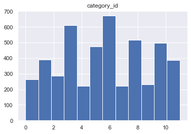

```python
data.hist(column='category_id', bins=12)
```

**Visualise the data**

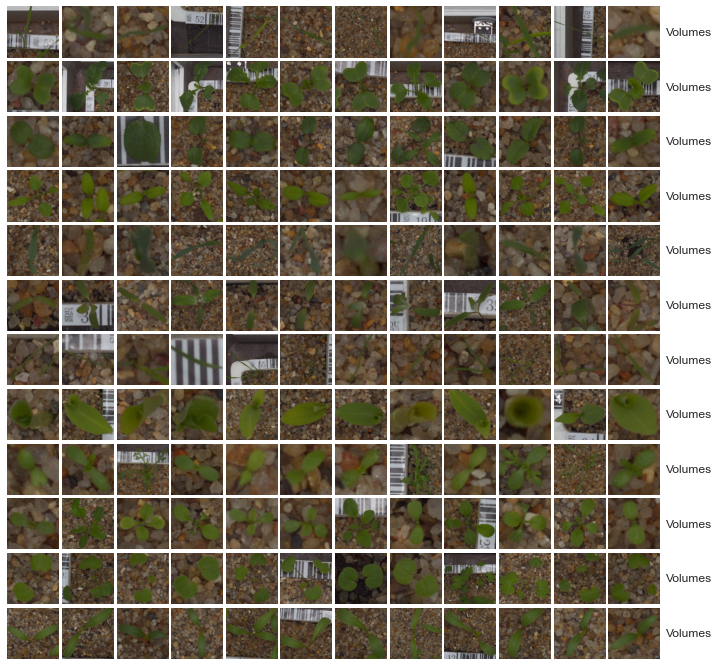

```python
def read_img(filepath, size):
    img = image.load_img(os.path.join(curr_path, filepath), target_size=size)
    img = image.img_to_array(img)
    return img
NUM_CATEGORIES = len(labels)
fig = plt.figure(1, figsize=(NUM_CATEGORIES, NUM_CATEGORIES))
grid = ImageGrid(fig, 111, nrows_ncols=(NUM_CATEGORIES, NUM_CATEGORIES), axes_pad=0.05)
i = 0
for category_id, category in enumerate(labels):
    for filepath in data[data['category'] == category]['filepath'].values[:NUM_CATEGORIES]:
        ax = grid[i]
        img = read_img(filepath, (224, 224))
        ax.imshow(img / 255.)
        ax.axis('off')
        if i % NUM_CATEGORIES == NUM_CATEGORIES - 1:
            ax.text(250, 112, filepath.split('/')[1], verticalalignment='center')
        i += 1
plt.show();
```

**Further analysis and preprocessing is done while trainging and testing the models below**

### 2. Design, train tune and test the best AIML image classifier model using:

**• Supervised learning algorithms**

**• Neural networks**

**• CNN**

**Train test split and analysis of shape of data**

```python
if sub_samples > 0:
    data = pd.concat([data[data['category'] == c][:sub_samples] for c in labels])
    data = data.sample(frac=1)
    data.index = np.arange(len(data))
    display(data.head(2))
    print(data.shape)
```

```python
np.random.seed(seed=SEED)
rnd = np.random.random(len(data))
train_idx = rnd > split
valid_idx = rnd <= split
train_y = data.loc[train_idx, 'category_id'].values
val_y = data.loc[valid_idx, 'category_id'].values
df_train_x = data.loc[train_idx, 'filepath'].values
df_val_x = data.loc[valid_idx, 'filepath'].values

print("{} images for train".format(len(df_train_x)))
print("{} images for validation".format(len(df_val_x)))
```

```
3814 images for train
953 images for validation
```

**Preprocessing functions and steps**

```python
def create_mask_for_plant(image):
    sensitivity=35    # Note: testé, c'est la meilleure valeur
    image_hsv = cv2.cvtColor(image, cv2.COLOR_BGR2HSV)
    lower_hsv = np.array([60 - sensitivity, 100, 50])
    upper_hsv = np.array([60 + sensitivity, 255, 255])

    mask = cv2.inRange(image_hsv, lower_hsv, upper_hsv)
    kernel = cv2.getStructuringElement(cv2.MORPH_ELLIPSE, (11,11))
    mask = cv2.morphologyEx(mask, cv2.MORPH_CLOSE, kernel)
    return mask

def segment_plant(image):
    mask = create_mask_for_plant(image)
    output = cv2.bitwise_and(image, image, mask = mask)
    return output

def sharpen_image(image):
    image_blurred = cv2.GaussianBlur(image, (0, 0), 3)
    image_sharp = cv2.addWeighted(image, 1.5, image_blurred, -0.5, 0)
    return image_sharp
```

```python
def preprocessing_cnn(img, mask_grass=False, nl_means=False):
    if mask_grass:
        img_segmented = segment_plant(img)
        img = sharpen_image(img_segmented)
    if nl_means:
        # Apply non-local means filter on test img
        img = cv2.fastNlMeansDenoisingColored(
            src=img.astype(np.uint8),
            dst=None,
            h=10,
            hColor=10,
            templateWindowSize=7,
            searchWindowSize=21)
    return img

def show_image_preprocc(image):
    image_mask = create_mask_for_plant(image)
    image_segmented = segment_plant(image)
    image_sharpen = sharpen_image(image_segmented)
    image_nlmeans = preprocessing_cnn(image_sharpen, nl_means=True)
    fig, axs = plt.subplots(1, 5, figsize=(20, 20))
    axs[0].imshow(image)
    axs[1].imshow(image_mask)
    axs[2].imshow(image_segmented)
    axs[3].imshow(image_sharpen)
    axs[4].imshow(image_nlmeans)
```

**Now preprocess and visualise the preprocessing**

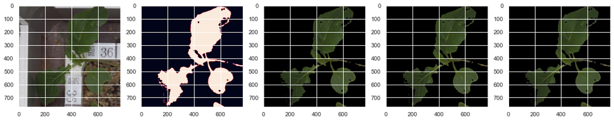

```python
class_indix = 1
img_indix = 1

list_files_cat = data['filepath'][data['category_id']==class_indix].reset_index(drop=True)
image_path = list_files_cat[img_indix]

image = cv2.imread(image_path)
image = cv2.cvtColor(image, cv2.COLOR_BGR2RGB)
show_image_preprocc(image)
```

```python
train_x = np.zeros((len(df_train_x), img_width, img_height, 3), dtype='float32')
for i, file in tqdm(enumerate(df_train_x)):
    img = cv2.imread(file)
    img = cv2.cvtColor(img, cv2.COLOR_BGR2RGB)
    img = cv2.resize(img, (img_width, img_height))
    img = preprocessing_cnn(img, mask_grass=detourage, nl_means=nl_means)
    img = tf.keras.utils.img_to_array(img)
    x = preprocess_input(np.expand_dims(img, axis=0))
    train_x[i] = x
print('Train Images shape: {} size: {:,}'.format(train_x.shape, train_x.size))
```

```
3814it [00:40, 94.12it/s]
```

```
Train Images shape: (3814, 299, 299, 3) size: 1,022,926,242
```

```python
val_x = np.zeros((len(df_val_x), img_width, img_height, 3), dtype='float32')
for i, file in tqdm(enumerate(df_val_x)):
    img = cv2.imread(file)
    img = cv2.cvtColor(img, cv2.COLOR_BGR2RGB)
    img = cv2.resize(img, (img_width, img_height))
    img = preprocessing_cnn(img, mask_grass=detourage, nl_means=nl_means)
    img = tf.keras.utils.img_to_array(img)
    x = preprocess_input(np.expand_dims(img, axis=0))
    val_x[i] = x
print('Validation Images shape: {} size: {:,}'.format(val_x.shape, val_x.size))
```

```
953it [00:09, 99.16it/s]
```

```
Validation Images shape: (953, 299, 299, 3) size: 255,597,459
```

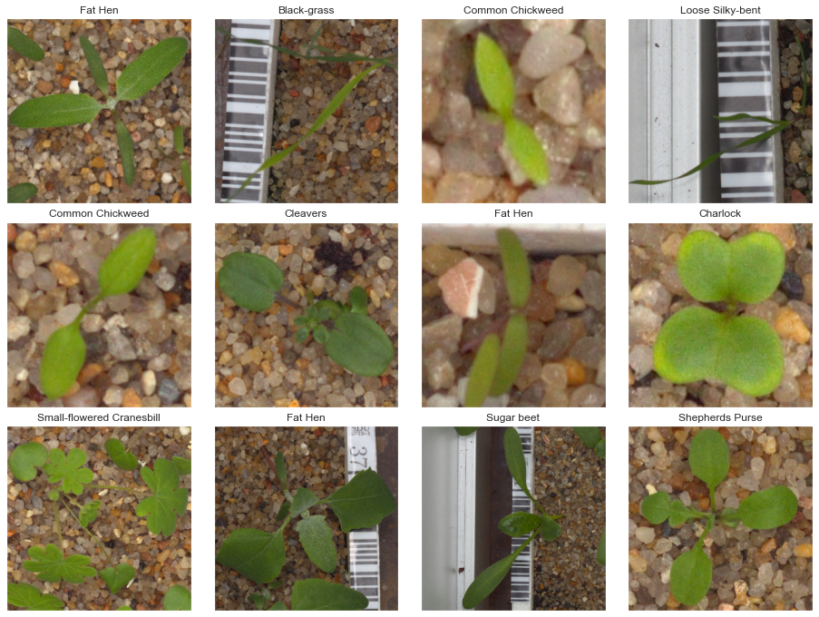

```python
y_true_s = [labels[y] for y in train_y]

sample_idxs = np.arange(len(train_x))
np.random.shuffle(sample_idxs)
picks = sample_idxs[:12]

fig = plt.figure(1, figsize=(16,12))
for i, r in enumerate(picks):
    plt.subplot(3,4,i+1)
    plt.subplots_adjust(hspace = 0.1, wspace = 0.1)
    plt.imshow(tf.keras.utils.array_to_img(train_x[r]))
    plt.title('{}'.format(y_true_s[r]))
    plt.xticks([]) , plt.yticks([])

plt.show()
```

### Modelling

```python
transfer_model = tf.keras.applications.xception.Xception(include_top=False, weights='imagenet', pooling='avg', input_shape=(img_height, img_width, 3))
INPUTOK = True
train_x_bf = transfer_model.predict(train_x, batch_size=batch_size, verbose=1)
val_x_bf = transfer_model.predict(val_x, batch_size=batch_size, verbose=1)
print('Xception train bottleneck features shape: {} size: {:,}'.format(train_x_bf.shape, train_x_bf.size))
print('Xception valid bottleneck features shape: {} size: {:,}'.format(val_x_bf.shape, val_x_bf.size))
```

```
Xception train bottleneck features shape: (3814, 2048) size: 7,811,072
Xception valid bottleneck features shape: (953, 2048) size: 1,951,744
```

```python
def plot_acc_loss(history, metrics = None):
    acc = history.history['accuracy']
    val_acc = history.history['val_accuracy']

    loss = history.history['loss']
    val_loss = history.history['val_loss']

    epochs_range = range(len(loss))

    num_subplot = 2
    if metrics is not None:
        num_subplot += len(metrics)

    plt.figure(figsize=(8+2*num_subplot, 8))
    plt.subplot(1, num_subplot, 1)
    plt.plot(epochs_range, acc, label='Training Accuracy')
    if val_acc is not None:
        plt.plot(epochs_range, val_acc, label='Validation Accuracy')
    plt.legend(loc='lower right')
    plt.title('Training and Validation Accuracy')

    plt.subplot(1, num_subplot, 2)
    plt.plot(epochs_range, loss, label='Training Loss')
    if val_loss is not None:
        plt.plot(epochs_range, val_loss, label='Validation Loss')
    plt.legend(loc='upper right')
    plt.title('Training and Validation Loss')

    if metrics is not None:
        for i, met in enumerate(metrics):
            m = history.history[met]
            val_m = history.history['val_'+met]
            plt.subplot(1, num_subplot, 3+i)
            plt.plot(epochs_range, m, label='Training '+met)
            if val_m is not None:
                plt.plot(epochs_range, val_m, label='Validation '+met)
            plt.legend()
            plt.title('Training and Validation '+met)

    plt.show()
```

### Classifier Models

```python
classifier = {}

def train_predict_score(model, train_x, train_y, val_x, val_y):
    t0 = dt.datetime.now()
    model.fit(train_x, train_y)
    val_preds = model.predict(val_x)
    val_probs = model.predict_proba(val_x)
    score = accuracy_score(val_y, val_preds)
    t = dt.datetime.now()-t0
    print('Train/Predict/Evaluate time: {} sec'.format(t.seconds))
    return val_preds, val_probs, score, t
```

### RandomForestClassifier

```python
if INPUTOK:
    rfc = RandomForestClassifier()
    val_pred, val_prob, score, t = train_predict_score(rfc, train_x_bf, train_y, val_x_bf, val_y)
    print('Validation Xception+RandomForestClassifier Accuracy {}'.format(score))

    classifier['rfc'] = (rfc, val_pred, val_prob, score, t)
```

```
Train/Predict/Evaluate time: 6 sec
Validation Xception+RandomForestClassifier Accuracy 0.7439664218258132
```

### LogisticRegression

```python
if INPUTOK:
    logreg = LogisticRegression(multi_class='multinomial', solver='sag', random_state=SEED, max_iter=200)
    val_pred, val_prob, score, t = train_predict_score(logreg, train_x_bf, train_y, val_x_bf, val_y)
    print('Validation Accuracy LogisticRegression]: {}'.format(score))

    classifier['logreg'] = (logreg, val_pred, val_prob, score, t)
```

```
Train/Predict/Evaluate time: 101 sec
Validation Accuracy LogisticRegression]: 0.8656873032528857
```

### SVM

```python
if INPUTOK:
    svm = SVC(kernel='rbf',probability=True)
    val_pred, val_prob, score, t = train_predict_score(svm, train_x_bf, train_y, val_x_bf, val_y)
    print('Validation SVM Accuracy {}'.format(score))

    classifier['svm'] = (svm, val_pred, val_prob, score, t)
```

```
Train/Predict/Evaluate time: 46 sec
Validation SVM Accuracy 0.8488982161594963
```

### Neural Network

```
Train/Predict/Evaluate time: 144 sec
```

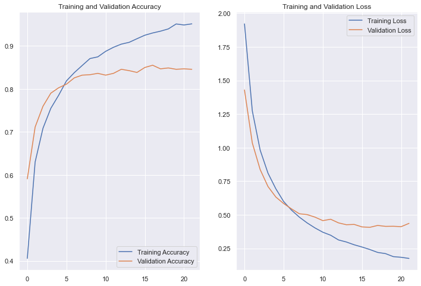

```
Validation Xception+Fully-connected Accuracy 0.8457502623294858
```

```python
if True:
    fully_connected = Sequential([
        Flatten(),
        Dense(100, activation='relu'),
        tf.keras.layers.BatchNormalization(trainable = False,axis=1),
        Dropout(0.2),
        Dense(50, activation='relu'),
        Dense(len(labels), activation='softmax')
    ])
    # Compiler le modèle
    optimizer = tf.keras.optimizers.Nadam(learning_rate=0.00004, beta_1=0.9, beta_2=0.999)
    fully_connected.compile(loss='sparse_categorical_crossentropy', optimizer=optimizer, metrics=['accuracy'])

    t0 = dt.datetime.now()
    history = fully_connected.fit(
        x = train_x_bf,
        y = train_y,
        steps_per_epoch= train_x.shape[0],
        epochs=30,
        validation_data=(val_x_bf, val_y),
        validation_steps=val_x_bf.shape[0],
        callbacks=[EarlyStopping(monitor='val_loss', patience=5)]
    )

    fc_valid_preds_res = fully_connected.predict(val_x_bf)
    fc_valid_preds = np.argmax(fc_valid_preds_res, axis=1)
    fc_valid_probs = np.max(fc_valid_preds_res, axis=1)
    fc_score = accuracy_score(val_y, fc_valid_preds)
    t = dt.datetime.now()-t0
    print('Train/Predict/Evaluate time: {} sec'.format(t.seconds))
    plot_acc_loss(history)
    print('Validation Xception+Fully-connected Accuracy {}'.format(fc_score))

    classifier['nn'] = (fully_connected, fc_valid_preds, fc_valid_probs, fc_score, t)
```

### CNN

```python
input_shape = train_x[1].shape
print('Input Shape is :', input_shape)
def fire_incept(x, fire=16, intercept=64):
    x = Conv2D(fire, (5,5), strides=(2,2))(x)
    x = LeakyReLU(alpha=0.15)(x)

    left = Conv2D(intercept, (3,3), padding='same')(x)
    left = LeakyReLU(alpha=0.15)(left)

    right = Conv2D(intercept, (5,5), padding='same')(x)
    right = LeakyReLU(alpha=0.15)(right)

    x = concatenate([left, right], axis=3)
    return x

def fire_squeeze(x, fire=16, intercept=64):
    x = Conv2D(fire, (1,1))(x)
    x = LeakyReLU(alpha=0.15)(x)

    left = Conv2D(intercept, (1,1))(x)
    left = LeakyReLU(alpha=0.15)(left)

    right = Conv2D(intercept, (3,3), padding='same')(x)
    right = LeakyReLU(alpha=0.15)(right)

    x = concatenate([left, right], axis=3)
    return x

image_input=Input(shape=input_shape)

x = fire_incept((image_input), fire=16, intercept=16)

x = fire_incept(x, fire=32, intercept=32)
x = fire_squeeze(x, fire=32, intercept=32)

x = fire_incept(x, fire=64, intercept=64)
x = fire_squeeze(x, fire=64, intercept=64)

x = fire_incept(x, fire=64, intercept=64)
x = fire_squeeze(x, fire=64, intercept=64)

x = Conv2D(64, (3,3))(x)
x = LeakyReLU(alpha=0.1)(x)

x = Flatten()(x)

x = Dense(512)(x)
x = LeakyReLU(alpha=0.1)(x)
x = Dropout(0.1)(x)

out = Dense(len(labels), activation='softmax')(x)

model_new = Model(image_input, out)
model_new.summary()
```

```
Input Shape is : (299, 299, 3)
Model: "model"
__________________________________________________________________________________________________
 Layer (type)                   Output Shape         Param #     Connected to
==================================================================================================
 input_4 (InputLayer)           [(None, 299, 299, 3  0           []
                                )]

 conv2d_12 (Conv2D)             (None, 148, 148, 16  1216        ['input_4[0][0]']
                                )

 leaky_re_lu (LeakyReLU)        (None, 148, 148, 16  0           ['conv2d_12[0][0]']
                                )

 conv2d_13 (Conv2D)             (None, 148, 148, 16  2320        ['leaky_re_lu[0][0]']
                                )

 conv2d_14 (Conv2D)             (None, 148, 148, 16  6416        ['leaky_re_lu[0][0]']
                                )

 leaky_re_lu_1 (LeakyReLU)      (None, 148, 148, 16  0           ['conv2d_13[0][0]']
                                )

 leaky_re_lu_2 (LeakyReLU)      (None, 148, 148, 16  0           ['conv2d_14[0][0]']
                                )

 concatenate (Concatenate)      (None, 148, 148, 32  0           ['leaky_re_lu_1[0][0]',
                                )                                 'leaky_re_lu_2[0][0]']

 conv2d_15 (Conv2D)             (None, 72, 72, 32)   25632       ['concatenate[0][0]']

 leaky_re_lu_3 (LeakyReLU)      (None, 72, 72, 32)   0           ['conv2d_15[0][0]']

 conv2d_16 (Conv2D)             (None, 72, 72, 32)   9248        ['leaky_re_lu_3[0][0]']

 conv2d_17 (Conv2D)             (None, 72, 72, 32)   25632       ['leaky_re_lu_3[0][0]']

 leaky_re_lu_4 (LeakyReLU)      (None, 72, 72, 32)   0           ['conv2d_16[0][0]']

 leaky_re_lu_5 (LeakyReLU)      (None, 72, 72, 32)   0           ['conv2d_17[0][0]']
```

[output cut: 83 more lines]

```
 flatten_1 (Flatten)            (None, 10816)        0           ['leaky_re_lu_21[0][0]']

 dense_3 (Dense)                (None, 512)          5538304     ['flatten_1[0][0]']

 leaky_re_lu_22 (LeakyReLU)     (None, 512)          0           ['dense_3[0][0]']

 dropout_1 (Dropout)            (None, 512)          0           ['leaky_re_lu_22[0][0]']

 dense_4 (Dense)                (None, 12)           6156        ['dropout_1[0][0]']

==================================================================================================
Total params: 6,385,900
Trainable params: 6,385,900
Non-trainable params: 0
__________________________________________________________________________________________________
```

**Note : Since we have with higher batch size, higher epochs and higher steps_per_epoch time to train is very high, we are taking less values for these parameters.**

```python
# compile model
model =model_new
model.compile(loss='categorical_crossentropy', optimizer='adam', metrics=['accuracy'])

# Use earlystopping
callback = tf.keras.callbacks.EarlyStopping(monitor='val_accuracy', patience=2, min_delta=0.01)

y_train = to_categorical(train_y, num_classes=len(labels))
y_val = to_categorical(val_y, num_classes=len(labels))

datagen = ImageDataGenerator(
        rotation_range=180,  # randomly rotate images in the range
        zoom_range = 0.1, # Randomly zoom image
        width_shift_range=0.1,  # randomly shift images horizontally
        height_shift_range=0.1,  # randomly shift images vertically
        horizontal_flip=True,  # randomly flip images horizontally
        vertical_flip=True  # randomly flip images vertically
    )
datagen.fit(train_x)

learning_rate_reduction = ReduceLROnPlateau(monitor='val_accuracy',
                                            patience=3,
                                            verbose=1,
                                            factor=0.4,
                                            min_lr=0.00001)
```

```python
hist = model.fit(x=train_x,y=y_train, batch_size=75,
                           epochs=10, validation_data=(val_x,y_val),
                           steps_per_epoch=train_x.shape[0]// 75, callbacks=[callback])
```

```python
hist = model.fit(x=train_x,y=y_train, batch_size=75,
                           epochs=10, validation_data=(val_x,y_val),
                           steps_per_epoch=train_x.shape[0]// 75, callbacks=[learning_rate_reduction])
```

```
Train/Predict/Evaluate time: 3774 sec
```

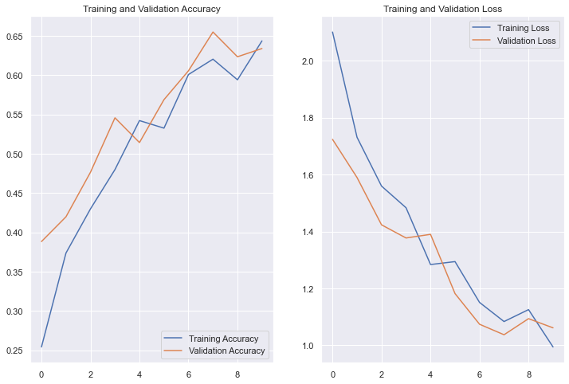

```
Validation Fully-connected Accuracy 0.633788037775446
```

```python
cnn_valid_preds_res = model.predict(val_x)
cnn_valid_preds = np.argmax(cnn_valid_preds_res, axis=1)
cnn_valid_probs = np.max(cnn_valid_preds_res, axis=1)
cnn_score = accuracy_score(val_y, cnn_valid_preds)
t = dt.datetime.now()-t0
print('Train/Predict/Evaluate time: {} sec'.format(t.seconds))
plot_acc_loss(hist)
print('Validation Fully-connected Accuracy {}'.format(cnn_score))

classifier['cnn'] = (model, cnn_valid_preds, cnn_valid_probs, cnn_score, t)
```

### 3. Compare the results from the above step along with your detailed observations on the best performing algorithm and why/how it outperforms other algorithms in this case.

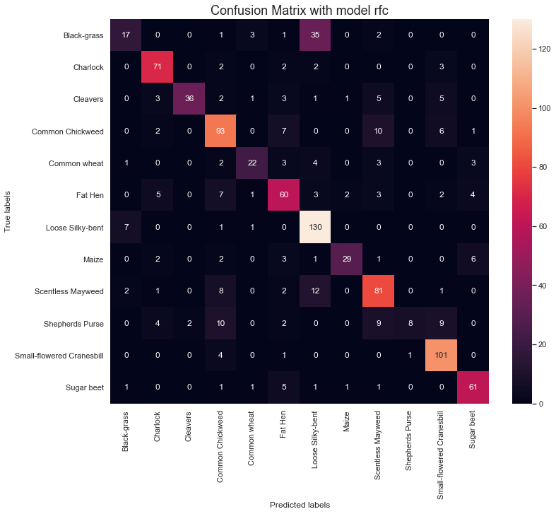

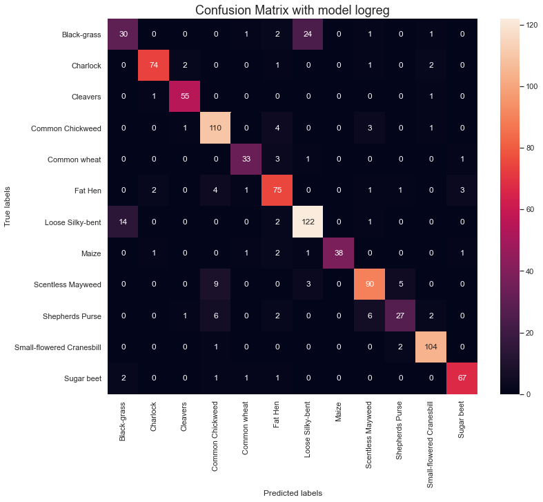

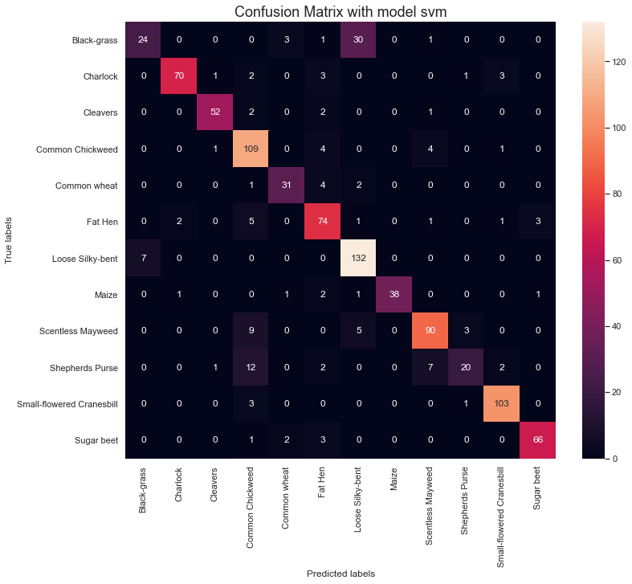

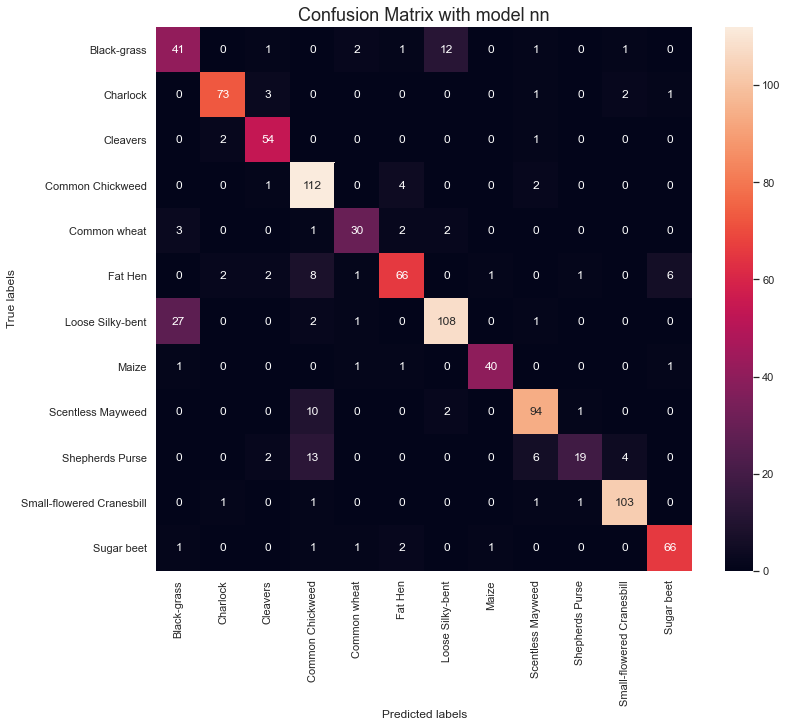

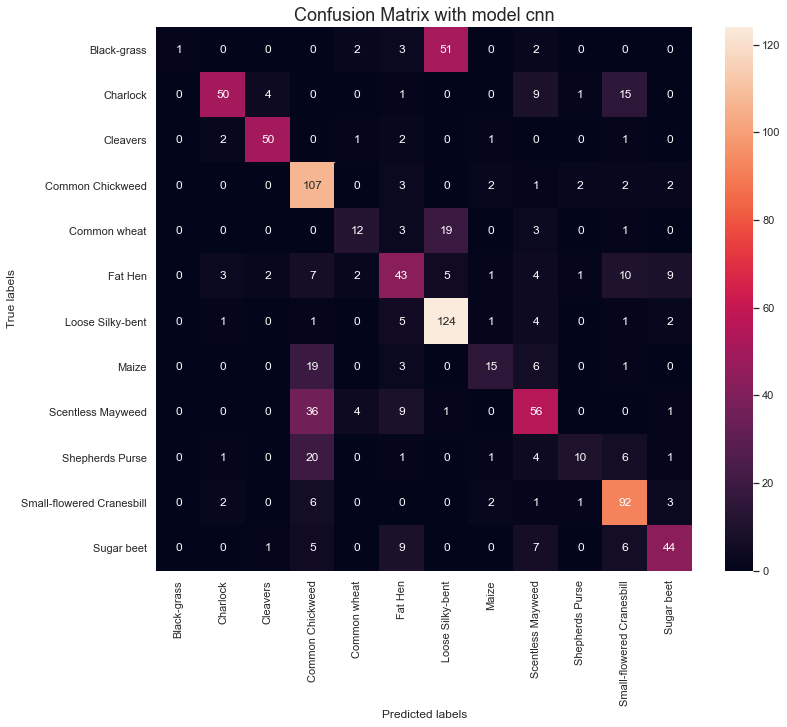

```python
import seaborn as sns
from sklearn.metrics import confusion_matrix

for key in classifier:
    # Use predictions
    y_pred = classifier[key][1]

    # Confusion Matrix
    cf_matrix = confusion_matrix(val_y, y_pred, labels=range(len(labels)))

    fig = plt.figure(figsize=(12,10))
    ax = sns.heatmap(cf_matrix, annot=True, fmt='d')
    ax.set_xlabel("Predicted labels")
    ax.set_ylabel("True labels")
    ax.xaxis.set_ticklabels(labels, rotation='vertical')
    ax.yaxis.set_ticklabels(labels, rotation='horizontal')
    plt.title("Confusion Matrix with model "+key, fontsize=18)
    plt.show()
```

```python
best_score = 0.0
best_classifier_key = ''
print("classifier \t score \t\t time")
for key in classifier:
    score = classifier[key][3]
    print("{}\t{}\t{}".format(key, score, classifier[key][4]))
    if score > best_score:
        best_score = score
        best_classifier_key = key
print("\nBest classifier: {}  - score: {}".format(best_classifier_key, best_score))
```

```
classifier 	 score 		 time
rfc	0.7439664218258132	0:00:06.837384
logreg	0.8656873032528857	0:01:41.477673
svm	0.8488982161594963	0:00:46.359884
nn	0.8457502623294858	0:02:24.928500
cnn	0.633788037775446	1:02:54.860561

Best classifier: logreg  - score: 0.8656873032528857
```

## INFERENCE AND CONCLUSION

| classifier | score | time |
| --- | --- | --- |
| Random forest Classifier | 0.7439664218258132 | 0:00:06.837384 |
| Logistic regression | 0.8656873032528857 | 0:01:41.477673 |
| SVM | 0.8488982161594963 | 0:00:46.359884 |
| NeuralNetwork | 0.8457502623294858 | 0:02:24.928500 |
| CNN | 0.633788037775446 | 1:02:54.860561 |

**We can see that the Neural network SVM and logistic regression are among the top accuracy.**

**The convolutional neural network is having accuracy of 0.633788037775446. Since we have to train with limited epochs due to timing. We could train the CNN more to get better results.**

**The timing for for the SVM is lesser compared to logistic regression and neural network**

**SVM is good in terms of timing and have good accuracy**

**Logistic regression is best in terms accuracy**

### 4. Pickle the best performing model.

```python
import pickle
filename = 'logreg_model.sav'
pickle.dump(logreg, open(filename, 'wb'))


fully_connected.save('nn_model.h5')
fully_connected.save_weights("nn_model_weights.h5")
print("Saved model to disk")
```

```
Saved model to disk
```

**Here we have pickle the logistic regression to logreg_model.sav file**

**Neural network is weights are saved on nn_model_weights.h5 file**

### 5. Import the the test image [ from the “ Prediction” folder ] to predict the class. Display the image. Use the best trained image classifier model to predict the class.

```
prediction(rfc): Maize  (79.0)
prediction(logreg): Maize  (99.89094734191895)
prediction(svm): Maize  (99.68202923291899)
prediction(nn): Maize  (99.98270869255066)
prediction(cnn): Common Chickweed  (50.31442046165466)
```

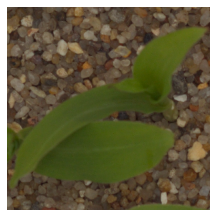

```python
image_path = os.path.join(curr_path,'Prediction/Predict.png')

image = cv2.imread(image_path)
image = cv2.cvtColor(image, cv2.COLOR_BGR2RGB)
image = cv2.resize(image, (img_width, img_height))

# show image
plt.figure(figsize=(8, 4))
plt.subplot(121)
plt.imshow(image)
plt.axis("off")

if detourage or nl_means:
    image = preprocessing_cnn(image, mask_grass=detourage, nl_means=nl_means)
    plt.subplot(122)
    plt.imshow(image)
    plt.axis("off")

img_array = tf.keras.utils.img_to_array(image)
img_array = preprocess_input(tf.expand_dims(img_array, 0))
img_bf = transfer_model.predict(img_array)

for key in classifier:
    if key == 'nn' :
        prediction = classifier[key][0].predict(img_bf)
        prediction_fc = np.argmax(prediction, axis=1)
        prediction_proba_fc = np.max(prediction, axis=1)
        print("prediction({}): {}  ({})".format(key, labels[prediction_fc[0]], 100*prediction_proba_fc[0]))
    elif key == 'cnn' :
        prediction = classifier[key][0].predict(img_array)
        prediction_cnn = np.argmax(prediction, axis=1)
        prediction_proba_cnn = np.max(prediction, axis=1)
        print("prediction({}): {}  ({})".format(key, labels[prediction_cnn[0]], 100*prediction_proba_cnn[0]))
    else:
        prediction = classifier[key][0].predict(img_bf)
        prediction_proba = classifier[key][0].predict_proba(img_bf)
        print("prediction({}): {}  ({})".format(key, labels[prediction[0]], 100*np.max(prediction_proba[0])))
```

## CONCLUSION :

**We have got good results and predicted the shape of the plant with different models.**

====================================================================================================================

# END

====================================================================================================================